# Final Project Predicting Coffee Consumption Using Multiple Linear Regression

Team 6 (Alex Frumkin, Tony Lim, Sara Nager, Jaanhvi Vaidya, Trisha Mathelier)

# Introduction

For our final project, we wanted to analyze coffee consumption (measured in grams) and to determine whether a multiple linear regression was applicable. We utilized datasets from the [National Health and Nutrition Examination Survey (NHANES) 2015-2016](https://wwwn.cdc.gov/nchs/nhanes/continuousnhanes/default.aspx?BeginYear=2015).

Specifically, we used

- [Demographics Data](https://wwwn.cdc.gov/Nchs/Nhanes/2015-2016/DEMO_I.htm) ([DEMO_I.XPT](https://wwwn.cdc.gov/nchs/nhanes/search/datapage.aspx?Component=Demographics&CycleBeginYear=2015))
- [Dietary Interview - Individual Foods, First Day](https://wwwn.cdc.gov/Nchs/Nhanes/2015-2016/DR1IFF_I.htm) ([DR1IFF_I.XPT](https://wwwn.cdc.gov/nchs/nhanes/search/datapage.aspx?Component=Dietary&CycleBeginYear=2015))
- [Dietary Interview Technical Support File - Food Codes](https://wwwn.cdc.gov/Nchs/Nhanes/2015-2016/DRXFCD_I.htm) ([DRXFCD_I.XPT](https://wwwn.cdc.gov/nchs/nhanes/search/datapage.aspx?Component=Dietary&CycleBeginYear=2015))

Variables in the `final` dataset include:

- **SEQN**: Respondent sequence number
- **TOTAL**: Total number of calories consumed
- **COFFEE_TOTAL**: Total number of grams attributable to coffee consumption
- **GENDER**: Gender
- **AGE**: Age in years at screening
- **RACE**: Race
  - Black
  - Hispanic
  - White
  - Other/Multi
- **EDUCATION**: Education level
  - Less than high school
  - Some high school
  - High school graduate/GED
  - Some college/AA
  - College graduate or above
  - Unsure
- **MARITAL**: Marital status
  - Married
  - Widowed
  - Divorced
  - Separated
  - Never married
  - Living with partner
  - Refused
  - Unsure
- **HH_SIZE**: Total number of people in the household
- **HH_INC**: Total household income
  - Below 20k
  - 20-45k
  - 45-75k
  - Above 75k
  - Refused
  - Unsure

# 1. Installing Libraries

```r
library(dplyr)
library(foreign)
library(ggplot2)
library(jtools)
library(ggpubr)
library(tidyverse)
library(wesanderson)
```

# 2. Data Preparation

## Demographic Dataset

```r
demo <- read.xport("DEMO_I.XPT")

(demo <- as_tibble(demo))
```

```
## # A tibble: 9,971 x 47
##     SEQN SDDSRVYR RIDSTATR RIAGENDR RIDAGEYR RIDAGEMN RIDRETH1 RIDRETH3 RIDEXMON
##    <dbl>    <dbl>    <dbl>    <dbl>    <dbl>    <dbl>    <dbl>    <dbl>    <dbl>
##  1 83732        9        2        1       62       NA        3        3        1
##  2 83733        9        2        1       53       NA        3        3        1
##  3 83734        9        2        1       78       NA        3        3        2
##  4 83735        9        2        2       56       NA        3        3        2
##  5 83736        9        2        2       42       NA        4        4        2
##  6 83737        9        2        2       72       NA        1        1        1
##  7 83738        9        2        2       11       NA        1        1        1
##  8 83739        9        2        1        4       NA        3        3        2
##  9 83740        9        2        1        1       13        2        2        2
## 10 83741        9        2        1       22       NA        4        4        1
## # ... with 9,961 more rows, and 38 more variables: RIDEXAGM <dbl>,
## #   DMQMILIZ <dbl>, DMQADFC <dbl>, DMDBORN4 <dbl>, DMDCITZN <dbl>,
## #   DMDYRSUS <dbl>, DMDEDUC3 <dbl>, DMDEDUC2 <dbl>, DMDMARTL <dbl>,
## #   RIDEXPRG <dbl>, SIALANG <dbl>, SIAPROXY <dbl>, SIAINTRP <dbl>,
## #   FIALANG <dbl>, FIAPROXY <dbl>, FIAINTRP <dbl>, MIALANG <dbl>,
## #   MIAPROXY <dbl>, MIAINTRP <dbl>, AIALANGA <dbl>, DMDHHSIZ <dbl>,
## #   DMDFMSIZ <dbl>, DMDHHSZA <dbl>, DMDHHSZB <dbl>, DMDHHSZE <dbl>,
## #   DMDHRGND <dbl>, DMDHRAGE <dbl>, DMDHRBR4 <dbl>, DMDHREDU <dbl>,
## #   DMDHRMAR <dbl>, DMDHSEDU <dbl>, WTINT2YR <dbl>, WTMEC2YR <dbl>,
## #   SDMVPSU <dbl>, SDMVSTRA <dbl>, INDHHIN2 <dbl>, INDFMIN2 <dbl>,
## #   INDFMPIR <dbl>
```

Converting DMDEDUC2 variable for those below 20 years of age to DMDEDUC3 variable

```r
demo$DMDEDUC2[demo$DMDEDUC3 < 10] <- 1
demo$DMDEDUC2[demo$DMDEDUC3 %in% c(9:12)] <- 2
demo$DMDEDUC2[demo$DMDEDUC3 %in% c(13, 14)] <- 3
demo$DMDEDUC2[demo$DMDEDUC3 == 15] <- 4
demo$DMDEDUC2[demo$DMDEDUC3 %in% c(55, 66)] <- 1
demo$DMDEDUC2[demo$DMDEDUC3 == 77] <- 7
demo$DMDEDUC2[demo$DMDEDUC3 == 99] <- 9
```

Selecting the desired variables and renaming them.

```r
(demo <- demo %>%
  select(SEQN, GENDER = RIAGENDR, AGE = RIDAGEYR, RACE = RIDRETH1, EDUCATION = DMDEDUC2, MARITAL = DMDMARTL, HH_SIZE = DMDHHSIZ,
         HH_INC = INDHHIN2))
```

```
## # A tibble: 9,971 x 8
##     SEQN GENDER   AGE  RACE EDUCATION MARITAL HH_SIZE HH_INC
##    <dbl>  <dbl> <dbl> <dbl>     <dbl>   <dbl>   <dbl>  <dbl>
##  1 83732      1    62     3         5       1       2     10
##  2 83733      1    53     3         3       3       1      4
##  3 83734      1    78     3         3       1       2      5
##  4 83735      2    56     3         5       6       1     10
##  5 83736      2    42     4         4       3       5      7
##  6 83737      2    72     1         2       4       5     14
##  7 83738      2    11     1         1      NA       5      6
##  8 83739      1     4     3        NA      NA       5     15
##  9 83740      1     1     2        NA      NA       7     77
## 10 83741      1    22     4         4       5       3      7
## # ... with 9,961 more rows
```

## Factorizing Variables

```r
demo$AGE <- cut(demo$AGE,
                 breaks = c(0, 15, 25, 35, 45, 55, 65, 75, Inf),
                 labels = c("Below 15", "15-25", "25-35", "35-45", "45-55", "55-65", "65-75", "Above 75"))

demo$GENDER <- factor(demo$GENDER,
                       labels = c("Male", "Female"))

demo$EDUCATION <- factor(demo$EDUCATION,
                        labels = c("Less than high school", "Some high school", "High school graduate/GED", "Some college/AA", "College graduate or above", "Unsure"))

demo$RACE <- factor(demo$RACE,
                     labels=c("Hispanic", "Hispanic", "White", "Black", "Other/Multi"))

# Filtered out 12 ($20,000 and Over) and 13 (Under $20,000)
demo <- demo %>%
  filter(!(HH_INC == 12 | HH_INC == 13))

demo$MARITAL <- factor(demo$MARITAL,
                        labels = c("Married", "Widowed", "Divorced", "Separated", "Never married", "Living with partner", "Refused", "Unsure"))

demo$HH_INC <- cut(demo$HH_INC,
                    breaks = c(0, 4.5, 7.5, 10.5, 76, 98, Inf),
                    labels = c("Below 20k", "20-45k", "45-75k", "Above 75k", "Refused", "Unsure"))

demo %>%
  print(width = Inf)
```

```
## # A tibble: 9,188 x 8
##     SEQN GENDER AGE      RACE     EDUCATION                 MARITAL
##    <dbl> <fct>  <fct>    <fct>    <fct>                     <fct>
##  1 83732 Male   55-65    White    College graduate or above Married
##  2 83733 Male   45-55    White    High school graduate/GED  Divorced
##  3 83734 Male   Above 75 White    High school graduate/GED  Married
##  4 83735 Female 55-65    White    College graduate or above Living with partner
##  5 83736 Female 35-45    Black    Some college/AA           Divorced
##  6 83737 Female 65-75    Hispanic Some high school          Separated
##  7 83738 Female Below 15 Hispanic Less than high school     <NA>
##  8 83739 Male   Below 15 White    <NA>                      <NA>
##  9 83740 Male   Below 15 Hispanic <NA>                      <NA>
## 10 83741 Male   15-25    Black    Some college/AA           Never married
##    HH_SIZE HH_INC
##      <dbl> <fct>
##  1       2 45-75k
##  2       1 Below 20k
##  3       2 20-45k
##  4       1 45-75k
##  5       5 20-45k
##  6       5 Above 75k
##  7       5 20-45k
##  8       5 Above 75k
##  9       7 Refused
## 10       3 20-45k
## # ... with 9,178 more rows
```

## Joining the Dietary and Food Code Datasets - `join`

Reading in the dietary dataset and selecting/renaming the desired variables.

```r
diet <- read.xport("DR1IFF_I.XPT")

(diet <- as_tibble(diet) %>%
  select(SEQN, KCAL = DR1IKCAL, GRAM = DR1IGRMS, USDA = DR1IFDCD))
```

```
## # A tibble: 121,481 x 4
##     SEQN  KCAL   GRAM     USDA
##    <dbl> <dbl>  <dbl>    <dbl>
##  1 83732     7 720    92101000
##  2 83732    14   4    91200040
##  3 83732    21   3.92 12210400
##  4 83732     0 240    94100100
##  5 83732   218  75    51101010
##  6 83732   153  28.6  81103080
##  7 83732    12 600    92410320
##  8 83732   629 204    27564060
##  9 83732    12  20    75506010
## 10 83732    10  10    74401010
## # ... with 121,471 more rows
```

Reading in the food code dataset and renaming the variables.

```r
food_code <- read.xport("DRXFCD_I.XPT")

(food_code <- as_tibble(food_code) %>%
  select(USDA = DRXFDCD, SHORT = DRXFCSD, LONG = DRXFCLD))
```

```
## # A tibble: 8,690 x 3
##        USDA SHORT                              LONG
##       <dbl> <fct>                              <fct>
##  1 11000000 MILK, HUMAN                        Milk, human
##  2 11100000 MILK, NFS                          Milk, NFS
##  3 11111000 MILK, WHOLE                        Milk, whole
##  4 11111100 MILK, LOW SODIUM, WHOLE            Milk, low sodium, whole
##  5 11111150 MILK, CALCIUM FORTIFIED, WHOLE     Milk, calcium fortified, whole
##  6 11111160 MILK, CALCIUM FORTIFIED, LOW FAT ~ Milk, calcium fortified, low fat~
##  7 11111170 MILK, CALCIUM FORTIFIED, FAT FREE~ Milk, calcium fortified, fat fre~
##  8 11112110 MILK, REDUCED FAT (2%)             Milk, reduced fat (2%)
##  9 11112120 MILK, ACIDOPHILUS, LOW FAT (1%)    Milk, acidophilus, low fat (1%)
## 10 11112130 MILK, ACIDOPHILUS, REDUCED FAT (2~ Milk, acidophilus, reduced fat (~
## # ... with 8,680 more rows
```

Combining the dietary dataset with the food code dataset to create `join`.

```r
join <- inner_join(diet, food_code, by = "USDA")

(join <- as_tibble(join))
```

```
## # A tibble: 121,481 x 6
##     SEQN  KCAL   GRAM    USDA SHORT                     LONG
##    <dbl> <dbl>  <dbl>   <dbl> <fct>                     <fct>
##  1 83732     7 720     9.21e7 COFFEE, BREWED            Coffee, brewed
##  2 83732    14   4     9.12e7 SUGAR SUBSTITUTE, SACCHA~ Sugar substitute, sacch~
##  3 83732    21   3.92  1.22e7 COFFEE CREAMER, POWDER    Coffee creamer, powder
##  4 83732     0 240     9.41e7 WATER, BOTTLED, UNSWEETE~ Water, bottled, unsweet~
##  5 83732   218  75     5.11e7 BREAD, WHITE, TOASTED     Bread, white, toasted
##  6 83732   153  28.6   8.11e7 MARGARINE-LIKE SPREAD, T~ Margarine-like spread, ~
##  7 83732    12 600     9.24e7 SOFT DRINK, COLA, DIET    Soft drink, cola, diet
##  8 83732   629 204     2.76e7 FRANKFURTER OR HOT DOG S~ Frankfurter or hot dog ~
##  9 83732    12  20     7.55e7 MUSTARD                   Mustard
## 10 83732    10  10     7.44e7 TOMATO CATSUP             Tomato catsup
## # ... with 121,471 more rows
```

## Calculating Total Calories - `total`

Calculating the total number of calories consumed.

```r
total <- join %>%
  group_by(SEQN) %>%
  mutate(TOTAL = sum(KCAL)) %>%
  select(SEQN, TOTAL)

(total <- total %>%
   distinct(SEQN, TOTAL))
```

```
## # A tibble: 8,505 x 2
## # Groups:   SEQN [8,505]
##     SEQN TOTAL
##    <dbl> <dbl>
##  1 83732  1781
##  2 83733  2964
##  3 83734  2482
##  4 83735  1340
##  5 83736   604
##  6 83737  1304
##  7 83738  1239
##  8 83739  1242
##  9 83740  1151
## 10 83741  2338
## # ... with 8,495 more rows
```

## Calculating Total Grams of Coffee - `coffee`

Selecting the relevant food codes such as coffee creamer and multiple forms of coffee (brewed, cappuccino, Cuban, espresso, iced, instant, latte, macchiato, etc.) while ommitting unrelated coffee products (coffee cake, Irish coffee, etc.).

```r
coffee_code <- food_code[c(393:405, 8254:8374, 8378), ]
(coffee_code <- as_tibble(coffee_code))
```

```
## # A tibble: 135 x 3
##        USDA SHORT                              LONG
##       <dbl> <fct>                              <fct>
##  1 12200100 COFFEE CREAMER, NFS                Coffee creamer, NFS
##  2 12210200 COFFEE CREAMER, LIQUID             Coffee creamer, liquid
##  3 12210210 COFFEE CREAMER, LIQUID, FLAVORED   Coffee creamer, liquid, flavored
##  4 12210260 COFFEE CREAMER, LIQUID, FAT FREE   Coffee creamer, liquid, fat free
##  5 12210270 COFFEE CREAMER, LIQUID, FAT FREE,~ Coffee creamer, liquid, fat free~
##  6 12210280 COFFEE CREAMER, LIQUID, FAT FREE,~ Coffee creamer, liquid, fat free~
##  7 12210310 COFFEE CREAMER, LIQUID, SUGAR FRE~ Coffee creamer, liquid, sugar fr~
##  8 12210400 COFFEE CREAMER, POWDER             Coffee creamer, powder
##  9 12210420 COFFEE CREAMER, POWDER, FLAVORED   Coffee creamer, powder, flavored
## 10 12210430 COFFEE CREAMER, POWDER, FAT FREE   Coffee creamer, powder, fat free
## # ... with 125 more rows
```

Finding the total number of grams attributable to consuming coffee or coffee-related products.

```r
coffee <- inner_join(join, coffee_code, by = "USDA")

coffee <- coffee %>%
  group_by(SEQN) %>%
  mutate(COFFEE_TOTAL = sum(GRAM)) %>%
  select(SEQN, COFFEE_TOTAL)

(coffee <- coffee %>%
  distinct(SEQN, COFFEE_TOTAL))
```

```
## # A tibble: 2,773 x 2
## # Groups:   SEQN [2,773]
##     SEQN COFFEE_TOTAL
##    <dbl>        <dbl>
##  1 83732         724.
##  2 83733         480
##  3 83734         777.
##  4 83735         480
##  5 83742         285
##  6 83747         360
##  7 83752         525
##  8 83757         840
##  9 83769         480
## 10 83773         480
## # ... with 2,763 more rows
```

## Final Dataset - `final`

First, we created `clean`, a dataset with `SEQN`, `TOTAL`, `COFFEE_TOTAL` using a left join between `total` and `coffee`.

```r
(clean <- left_join(total, coffee, by = "SEQN"))
```

```
## # A tibble: 8,505 x 3
## # Groups:   SEQN [8,505]
##     SEQN TOTAL COFFEE_TOTAL
##    <dbl> <dbl>        <dbl>
##  1 83732  1781         724.
##  2 83733  2964         480
##  3 83734  2482         777.
##  4 83735  1340         480
##  5 83736   604          NA
##  6 83737  1304          NA
##  7 83738  1239          NA
##  8 83739  1242          NA
##  9 83740  1151          NA
## 10 83741  2338          NA
## # ... with 8,495 more rows
```

Then we created `final` using inner join `clean` with `demo`.

```r
final <- inner_join(clean, demo, by = "SEQN")

final$COFFEE_TOTAL <- replace_na(final$COFFEE_TOTAL, 0)

(final <- as_tibble(final))
```

```
## # A tibble: 7,923 x 10
##     SEQN TOTAL COFFEE_TOTAL GENDER AGE    RACE  EDUCATION MARITAL HH_SIZE HH_INC
##    <dbl> <dbl>        <dbl> <fct>  <fct>  <fct> <fct>     <fct>     <dbl> <fct>
##  1 83732  1781         724. Male   55-65  White College ~ Married       2 45-75k
##  2 83733  2964         480  Male   45-55  White High sch~ Divorc~       1 Below~
##  3 83734  2482         777. Male   Above~ White High sch~ Married       2 20-45k
##  4 83735  1340         480  Female 55-65  White College ~ Living~       1 45-75k
##  5 83736   604           0  Female 35-45  Black Some col~ Divorc~       5 20-45k
##  6 83737  1304           0  Female 65-75  Hisp~ Some hig~ Separa~       5 Above~
##  7 83738  1239           0  Female Below~ Hisp~ Less tha~ <NA>          5 20-45k
##  8 83739  1242           0  Male   Below~ White <NA>      <NA>          5 Above~
##  9 83740  1151           0  Male   Below~ Hisp~ <NA>      <NA>          7 Refus~
## 10 83741  2338           0  Male   15-25  Black Some col~ Never ~       3 20-45k
## # ... with 7,913 more rows
```

# 3. Data Visualization

## Age distribution

```r
age.p <- final %>%
  filter(!is.na(AGE)) %>%
  ggplot(mapping = aes(x = AGE)) +
  geom_bar(fill = "#fff1d8", color = "white") +
  labs(title = "Age distribution",
       x = "Age",
       y = "Count") +
  theme_minimal() +
  theme(axis.text.x = element_text(angle = 90, hjust = 1))
```

## Education distribution

```r
education.p <- final %>%
  ggplot(mapping = aes(x = EDUCATION)) +
  geom_bar(fill = "#a06d4c", color = "white") +
  labs(title = "Education distribution",
       x = "Education",
       y = "Count") +
  theme_minimal() +
  coord_flip() +
  scale_x_discrete(limits = rev(levels(final$EDUCATION)))
```

## Race distribution

```r
race.p <- final %>%
  ggplot(mapping = aes(x = RACE)) +
  geom_bar(fill = "#dc9265", color = "white") +
  labs(title = "Race distribution",
       x = "Race",
       y = "Count") +
  theme_minimal()
```

## Household income distribution

```r
hh_inc.p <- final %>%
  ggplot(mapping = aes(x = HH_INC)) +
  geom_bar(fill = "#ee7936", color = "white") +
  labs(title = "Household income distribution",
       x = "Household income",
       y = "Count") +
  theme_minimal() +
  theme(axis.text.x = element_text(angle = 90, hjust = 1))
```

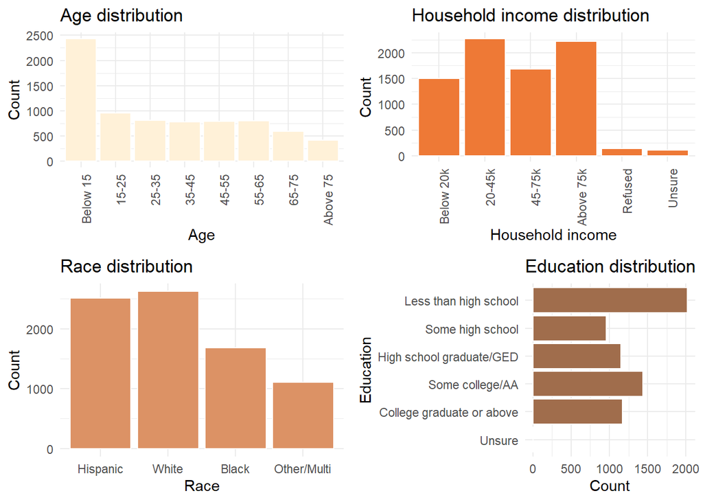

```r
ggarrange(age.p,  hh_inc.p,
          race.p, education.p,
          ncol = 2,
          nrow = 2)
```

## Household size distribution

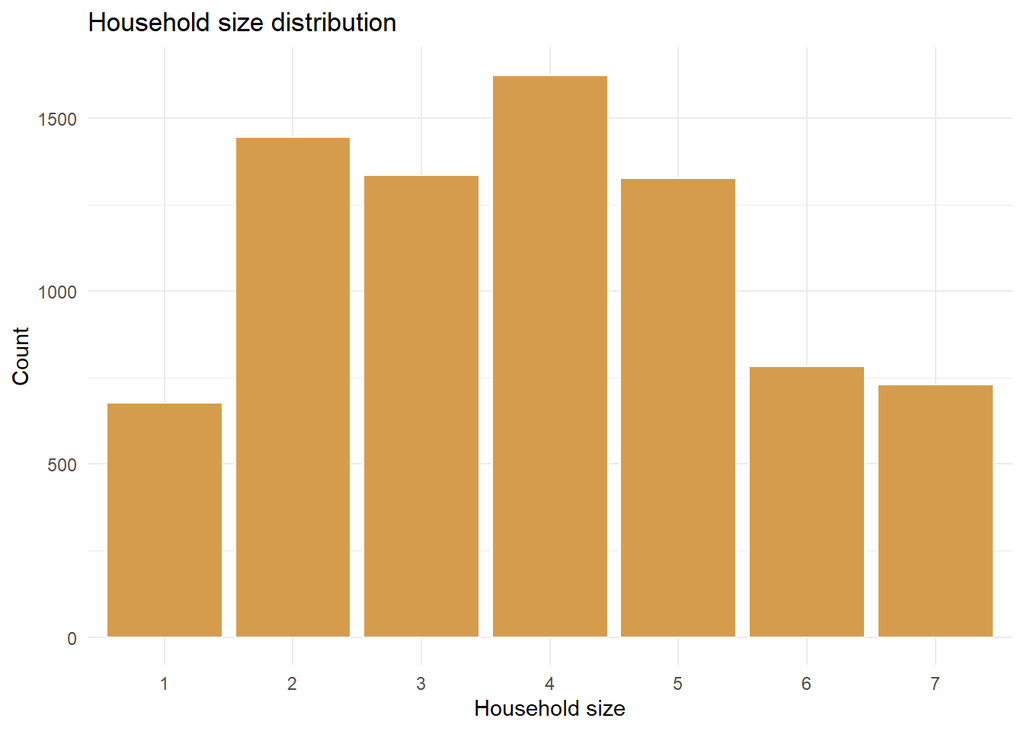

```r
final %>%
  ggplot(mapping = aes(x = HH_SIZE)) +
  geom_bar(fill = "#D69C4E", color = "white") +
  labs(title = "Household size distribution",
       x = "Household size",
       y = "Count") +
  scale_x_discrete(limits = c(1:7)) +
  theme_minimal()
```

```r
total.p <- final %>%
  ggplot(mapping = aes(x = TOTAL)) +
  geom_histogram(fill = "#a06d4c", color = "white") +
  labs(title = "Distribution of calories",
       x = "Calories",
       y = "Count") +
  theme_minimal()
```

```r
total_gender.p <- final %>%
  ggplot(mapping = aes(x = TOTAL, fill = GENDER)) +
  geom_histogram(color = "white") +
  labs(title = "Distribution of calories by gender",
       x = "Calories",
       y = "Count") +
  theme_minimal() +
  scale_fill_manual(name = "Gender", values = c("#ee7936", "#599ed6")) +
  facet_wrap(~ GENDER)
```

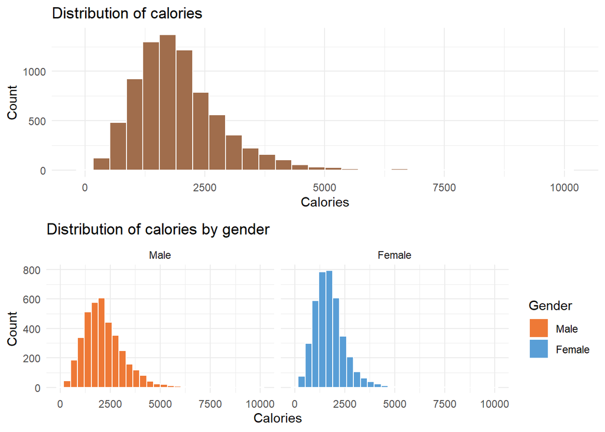

```r
ggarrange(total.p,
          total_gender.p,
          ncol = 1)
```

## Distribution of coffee consumption

```r
coffee_total.p <- final %>%
  ggplot(mapping = aes(x = COFFEE_TOTAL)) +
  geom_histogram(fill = "#a06d4c", color = "white") +
  labs(title = "Distribution of coffee consumption",
       x = "Coffee consumption (grams)",
       y = "Count") +
  theme_minimal()
```

## Distribution of coffee consumption by gender

```r
coffee_total_gender.p <- final %>%
  ggplot() +
  geom_histogram(mapping = aes(x = COFFEE_TOTAL, fill = GENDER), color = "white") +
  labs(title = "Distribution of coffee consumption by gender",
       x = "Coffee consumption (grams)",
       y = "Count") +
  scale_fill_manual(name = "Gender", values = c("#ee7936", "#599ed6")) +
  facet_wrap(~ GENDER) +
  theme_minimal()
```

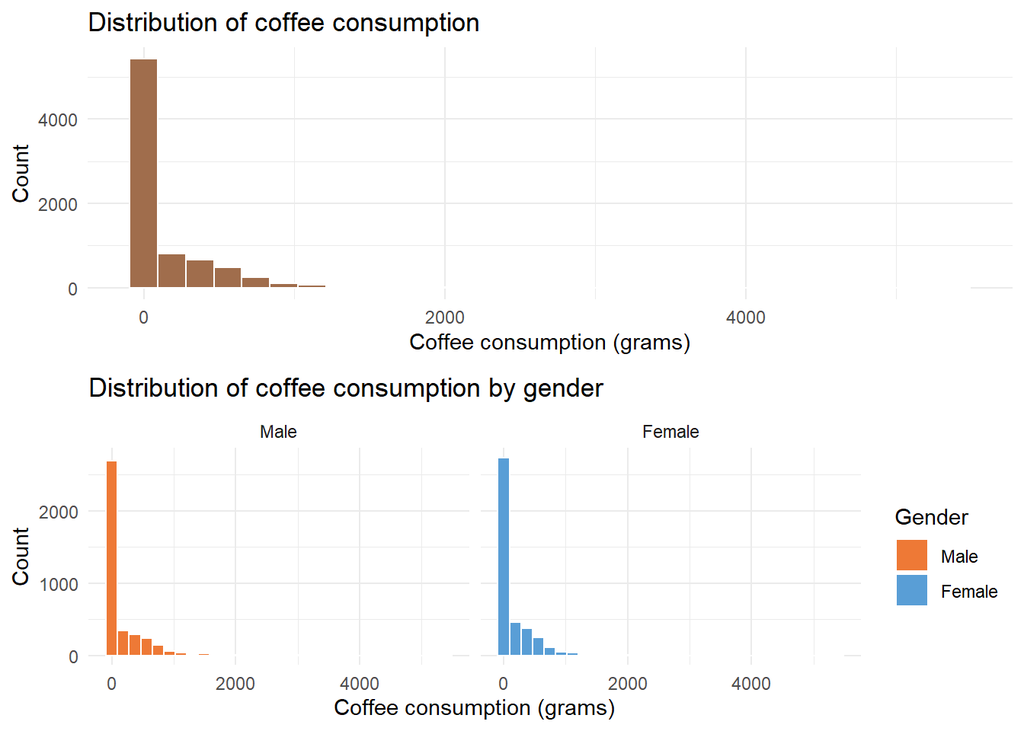

```r
ggarrange(coffee_total.p,
          coffee_total_gender.p,
          ncol = 1)
```

```r
avgcoffee_education.p <- final %>%
  filter(!is.na(EDUCATION)) %>%
  group_by(EDUCATION) %>%
  mutate(COFFEE_EDUCATION = mean(COFFEE_TOTAL)) %>%
  select(EDUCATION, COFFEE_EDUCATION) %>%
  distinct(EDUCATION, COFFEE_EDUCATION) %>%
  ggplot() +
  geom_bar(mapping = aes(x = EDUCATION, y = COFFEE_EDUCATION),
           fill = "#a06d4c",
           stat = "identity") +
  labs(title = "Average coffee consumption by education",
       x = "Education",
       y = "Average coffee consumption (grams)") +
  theme_minimal() +
  coord_flip() +
  scale_x_discrete(limits = rev(levels(final$EDUCATION)))
```

```r
avgcoffee_race.p <- final %>%
  #filter(!is.na(EDUCATION)) %>%
  group_by(RACE) %>%
  mutate(COFFEE_RACE = mean(COFFEE_TOTAL)) %>%
  select(RACE, COFFEE_RACE) %>%
  distinct(RACE, COFFEE_RACE) %>%
  ggplot() +
  geom_bar(mapping = aes(x = RACE, y = COFFEE_RACE),
           fill = "#dc9265",
           stat = "identity") +
  labs(title = "Average coffee consumption by race",
       x = "Race",
       y = "Average coffee consumption (grams)") +
  theme_minimal()
```

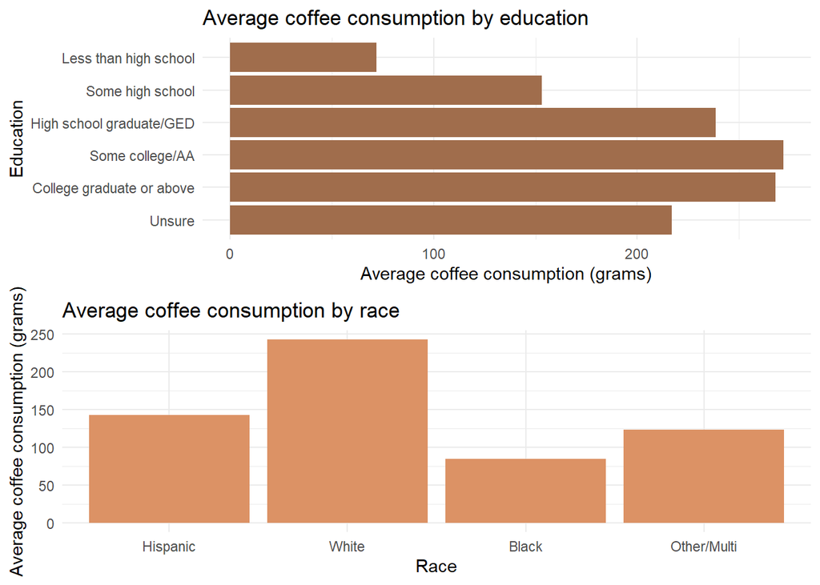

```r
ggarrange(avgcoffee_education.p,
          avgcoffee_race.p,
          ncol = 1)
```

## Distribution coffee consumption by age

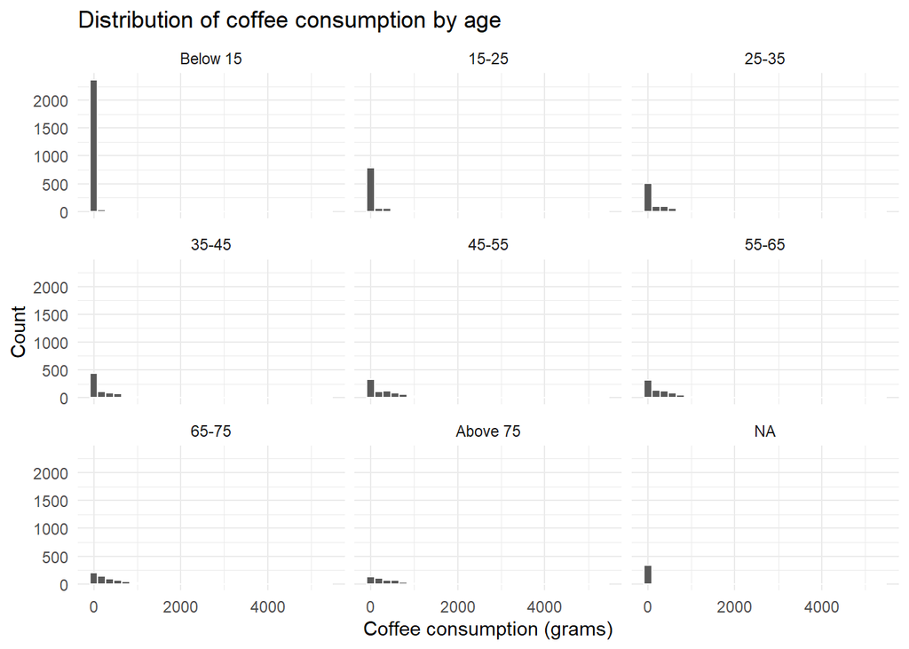

```r
final %>%
  ggplot() +
  geom_histogram(mapping = aes(x = COFFEE_TOTAL), color = "white") +
  labs(title = "Distribution of coffee consumption by age",
       x = "Coffee consumption (grams)",
       y = "Count") +
  #scale_fill_manual(name = "Coffee consumption (grams)", values = wes_palette("Moonrise2")) +
  facet_wrap(~ AGE) +
  theme_minimal()
```

## Distribution of coffee consumption by race

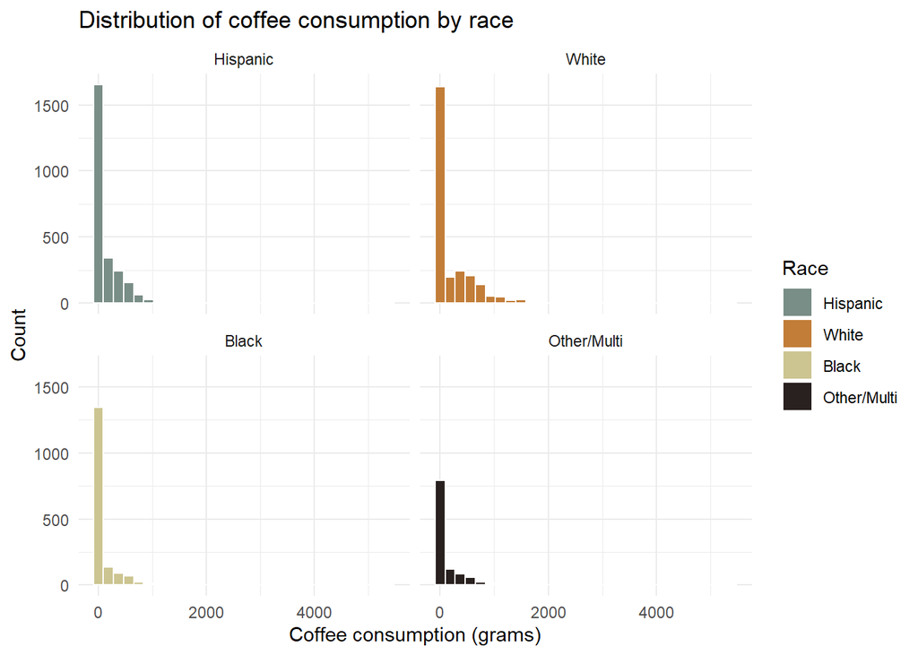

```r
final %>%
  ggplot() +
  geom_histogram(mapping = aes(x = COFFEE_TOTAL, fill = RACE), color = "white") +
  labs(title = "Distribution of coffee consumption by race",
       x = "Coffee consumption (grams)",
       y = "Count") +
  scale_fill_manual(name = "Race", values = wes_palette("Moonrise2")) +
  facet_wrap(~ RACE) +
  theme_minimal()
```

## Distribution of coffee consumption by education

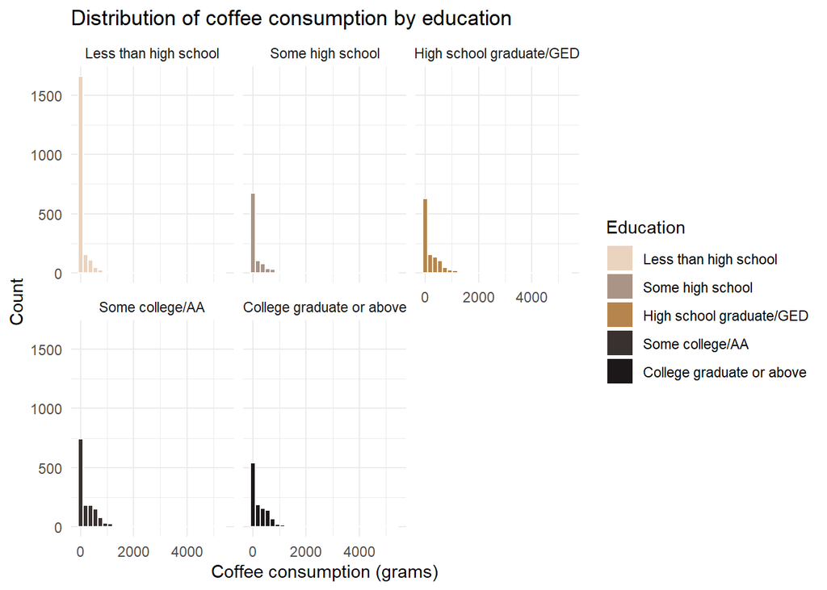

```r
final %>%
  filter(!(EDUCATION == "Unsure" | is.na(EDUCATION))) %>%
  ggplot() +
  geom_histogram(mapping = aes(x = COFFEE_TOTAL, fill = EDUCATION), color = "white") +
  labs(title = "Distribution of coffee consumption by education",
       x = "Coffee consumption (grams)",
       y = "Count") +
  scale_fill_manual(name = "Education", values = wes_palette("IsleofDogs2")) +
  facet_wrap(~ EDUCATION) +
  theme_minimal()
```

# 4. Data Analysis

```r
summary(final)
```

```
##       SEQN           TOTAL        COFFEE_TOTAL       GENDER           AGE
##  Min.   :83732   Min.   :  110   Min.   :   0.0   Male  :3872   Below 15:2431
##  1st Qu.:86203   1st Qu.: 1316   1st Qu.:   0.0   Female:4051   15-25   : 958
##  Median :88727   Median : 1811   Median :   0.0                 25-35   : 816
##  Mean   :88715   Mean   : 1953   Mean   : 160.7                 55-65   : 799
##  3rd Qu.:91197   3rd Qu.: 2408   3rd Qu.: 245.0                 45-55   : 793
##  Max.   :93702   Max.   :10126   Max.   :5400.0                 (Other) :1789
##                  NA's   :172                                    NA's    : 337
##           RACE                          EDUCATION                   MARITAL
##  Hispanic   :2512   Less than high school    :2019   Married            :2384
##  White      :2622   Some high school         : 961   Never married      : 829
##  Black      :1681   High school graduate/GED :1150   Divorced           : 497
##  Other/Multi:1108   Some college/AA          :1438   Living with partner: 441
##                     College graduate or above:1170   Widowed            : 326
##                     Unsure                   :   3   (Other)            : 160
##                     NA's                     :1182   NA's               :3286
##     HH_SIZE            HH_INC
##  Min.   :1.000   Below 20k:1497
##  1st Qu.:2.000   20-45k   :2276
##  Median :4.000   45-75k   :1679
##  Mean   :3.851   Above 75k:2223
##  3rd Qu.:5.000   Refused  : 137
##  Max.   :7.000   Unsure   : 111
##
```

```r
final[which.max(final$COFFEE_TOTAL), ]
```

```
## # A tibble: 1 x 10
##    SEQN TOTAL COFFEE_TOTAL GENDER AGE   RACE  EDUCATION   MARITAL HH_SIZE HH_INC
##   <dbl> <dbl>        <dbl> <fct>  <fct> <fct> <fct>       <fct>     <dbl> <fct>
## 1 85523  2608         5400 Male   35-45 White Some colle~ Married       2 Above~
```

```r
tapply(final$TOTAL, final$GENDER, mean, na.rm = T)
```

```
##     Male   Female
## 2174.622 1741.102
```

```r
tapply(final$COFFEE_TOTAL, final$GENDER, mean, na.rm = T)
```

```
##     Male   Female
## 171.5573 150.2946
```

```r
tapply(final$COFFEE_TOTAL, final$GENDER, median)
```

```
##   Male Female
##      0      0
```

```r
tapply(final$TOTAL, final$EDUCATION, mean, na.rm = T)
```

```
##     Less than high school          Some high school  High school graduate/GED
##                  1926.207                  2067.033                  2089.359
##           Some college/AA College graduate or above                    Unsure
##                  2114.894                  2127.022                  1332.667
```

```r
tapply(final$COFFEE_TOTAL, final$EDUCATION, mean, na.rm = T)
```

```
##     Less than high school          Some high school  High school graduate/GED
##                  71.88182                 153.09245                 238.65568
##           Some college/AA College graduate or above                    Unsure
##                 271.77626                 268.11680                 217.00000
```

```r
tapply(final$TOTAL, final$RACE, mean, na.rm = T)
```

```
##    Hispanic       White       Black Other/Multi
##    1935.297    2003.808    1936.366    1899.559
```

```r
tapply(final$COFFEE_TOTAL, final$RACE, mean, na.rm = T)
```

```
##    Hispanic       White       Black Other/Multi
##    142.6155    242.5616     84.6081    123.3217
```

```r
final %>%
  t.test(COFFEE_TOTAL ~ GENDER, data = ., var.equal = TRUE)
```

```
##
##  Two Sample t-test
##
## data:  COFFEE_TOTAL by GENDER
## t = 2.7773, df = 7921, p-value = 0.005495
## alternative hypothesis: true difference in means is not equal to 0
## 95 percent confidence interval:
##   6.255004 36.270375
## sample estimates:
##   mean in group Male mean in group Female
##             171.5573             150.2946
```

# 5. Multiple Linear Regression

```r
reg <- glm(COFFEE_TOTAL ~ GENDER + AGE + RACE + EDUCATION + MARITAL + HH_SIZE + HH_INC, data = final)
summary(reg)
```

```
##
## Call:
## glm(formula = COFFEE_TOTAL ~ GENDER + AGE + RACE + EDUCATION +
##     MARITAL + HH_SIZE + HH_INC, data = final)
##
## Deviance Residuals:
##    Min      1Q  Median      3Q     Max
## -536.2  -226.4   -77.7   123.2  4989.8
##
## Coefficients:
##                                     Estimate Std. Error t value Pr(>|t|)
## (Intercept)                         156.2062    37.5421   4.161 3.23e-05 ***
## GENDERFemale                        -41.7051    11.7013  -3.564 0.000369 ***
## AGE25-35                             43.1737    24.0667   1.794 0.072891 .
## AGE35-45                             96.7948    25.1835   3.844 0.000123 ***
## AGE45-55                            181.5582    25.7628   7.047 2.09e-12 ***
## AGE55-65                            215.4746    26.2969   8.194 3.24e-16 ***
## AGE65-75                            158.9035    28.3880   5.598 2.30e-08 ***
## AGEAbove 75                         141.1928    31.8752   4.430 9.66e-06 ***
## RACEWhite                           124.9840    15.8132   7.904 3.36e-15 ***
## RACEBlack                          -105.9548    17.1879  -6.165 7.67e-10 ***
## RACEOther/Multi                     -26.9213    19.7035  -1.366 0.171905
## EDUCATIONSome high school             5.8851    24.8704   0.237 0.812953
## EDUCATIONHigh school graduate/GED     3.7126    22.5010   0.165 0.868955
## EDUCATIONSome college/AA             25.1751    22.3026   1.129 0.259041
## EDUCATIONCollege graduate or above   -0.5094    24.2029  -0.021 0.983209
## EDUCATIONUnsure                      54.3476   276.9407   0.196 0.844429
## MARITALWidowed                       11.7491    25.9438   0.453 0.650666
## MARITALDivorced                      10.2728    20.3127   0.506 0.613069
## MARITALSeparated                     -3.6636    32.6995  -0.112 0.910798
## MARITALNever married                -42.8972    18.4990  -2.319 0.020445 *
## MARITALLiving with partner           21.9353    21.2939   1.030 0.303006
## MARITALRefused                      433.8209   390.5636   1.111 0.266731
## HH_SIZE                              -9.3475     3.9879  -2.344 0.019124 *
## HH_INC20-45k                         13.4352    17.4574   0.770 0.441579
## HH_INC45-75k                         19.5981    19.4588   1.007 0.313911
## HH_INCAbove 75k                      25.6866    19.7809   1.299 0.194162
## HH_INCRefused                       -31.0664    45.0891  -0.689 0.490858
## HH_INCUnsure                         -5.6526    46.1937  -0.122 0.902614
## ---
## Signif. codes:  0 '***' 0.001 '**' 0.01 '*' 0.05 '.' 0.1 ' ' 1
##
## (Dispersion parameter for gaussian family taken to be 151889.5)
##
##     Null deviance: 775946643  on 4636  degrees of freedom
## Residual deviance: 700058728  on 4609  degrees of freedom
##   (3286 observations deleted due to missingness)
## AIC: 68513
##
## Number of Fisher Scoring iterations: 2
```

```r
reg2 <- glm(COFFEE_TOTAL ~ GENDER + AGE + RACE + EDUCATION + HH_SIZE, data = final)
summary(reg2)
```

```
##
## Call:
## glm(formula = COFFEE_TOTAL ~ GENDER + AGE + RACE + EDUCATION +
##     HH_SIZE, data = final)
##
## Deviance Residuals:
##    Min      1Q  Median      3Q     Max
## -486.7  -165.1   -43.0    72.7  5042.3
##
## Coefficients:
##                                    Estimate Std. Error t value Pr(>|t|)
## (Intercept)                          51.363     18.037   2.848 0.004417 **
## GENDERFemale                        -27.080      8.071  -3.355 0.000798 ***
## AGE15-25                             44.973     19.032   2.363 0.018152 *
## AGE25-35                            130.290     19.494   6.684 2.52e-11 ***
## AGE35-45                            187.405     19.239   9.741  < 2e-16 ***
## AGE45-55                            276.838     19.266  14.369  < 2e-16 ***
## AGE55-65                            309.678     19.321  16.028  < 2e-16 ***
## AGE65-75                            262.423     20.343  12.900  < 2e-16 ***
## AGEAbove 75                         254.431     22.056  11.536  < 2e-16 ***
## RACEWhite                            87.669     10.673   8.214 2.55e-16 ***
## RACEBlack                           -83.519     11.595  -7.203 6.53e-13 ***
## RACEOther/Multi                     -24.989     13.342  -1.873 0.061120 .
## EDUCATIONSome high school             2.034     16.982   0.120 0.904663
## EDUCATIONHigh school graduate/GED    16.308     17.195   0.948 0.342965
## EDUCATIONSome college/AA             44.773     16.800   2.665 0.007717 **
## EDUCATIONCollege graduate or above   24.023     17.706   1.357 0.174910
## EDUCATIONUnsure                      38.420    190.966   0.201 0.840559
## HH_SIZE                              -6.754      2.732  -2.472 0.013451 *
## ---
## Signif. codes:  0 '***' 0.001 '**' 0.01 '*' 0.05 '.' 0.1 ' ' 1
##
## (Dispersion parameter for gaussian family taken to be 108978.7)
##
##     Null deviance: 884504612  on 6740  degrees of freedom
## Residual deviance: 732663901  on 6723  degrees of freedom
##   (1182 observations deleted due to missingness)
## AIC: 97338
##
## Number of Fisher Scoring iterations: 2
```

```r
tony <- data.frame(
  GENDER = "Male",
  AGE = "15-25",
  RACE = "Other/Multi",
  EDUCATION = "College graduate or above",
  HH_SIZE = 1
  )
```

```r
predict(reg2, newdata = tony)
```

```
##        1
## 88.61694
```

# Bonus

Finding the coffee products with the highest average calories.

```r
diet <- read.xport("DR1IFF_I.XPT")

diet <- diet %>%
  select(SEQN, KCAL = DR1IKCAL, GRAMS = DR1IGRMS, USDA = DR1IFDCD)

avgkcal <- right_join(diet, coffee_code, by = "USDA") %>%
  group_by(USDA) %>%
  mutate(AVGKCAL = mean(KCAL / GRAMS) * mean(GRAMS)) %>%
  select(USDA, AVGKCAL, SHORT, LONG) %>%
  distinct(.) %>%
  arrange(-(AVGKCAL))

right_join(diet, coffee_code, by = "USDA") %>%
  group_by(USDA) %>%
  mutate(AVGKCAL = mean(KCAL)) %>%
  select(USDA, AVGKCAL, SHORT, LONG) %>%
  distinct(.) %>%
  arrange(-(AVGKCAL))
```

```
## # A tibble: 135 x 4
## # Groups:   USDA [135]
##        USDA AVGKCAL SHORT                          LONG
##       <dbl>   <dbl> <fct>                          <fct>
##  1 92102030    453  FROZEN MOCHA COFFEE DRINK, WI~ Frozen mocha coffee drink, w~
##  2 92101906    348  COFFEE, LATTE, WITH NON-DAIRY~ Coffee, Latte, with non-dair~
##  3 92101925    329. FROZEN COFFEE DRINK, WITH WHI~ Frozen coffee drink, with wh~
##  4 92171000    274. COFFEE, BOTTLED/CANNED         Coffee, bottled/canned
##  5 92101920    272. FROZEN COFFEE DRINK            Frozen coffee drink
##  6 92102600    270. COFFEE, ICED CAFE MOCHA        Coffee, Iced Cafe Mocha
##  7 92101917    268. COFFEE, LATTE, DECAFFEINATED,~ Coffee, Latte, decaffeinated~
##  8 92101950    261. COFFEE, CAFE MOCHA             Coffee, Cafe Mocha
##  9 92102040    260  FROZEN MOCHA COFFEE DRINK, NO~ Frozen mocha coffee drink, n~
## 10 92101921    221  FROZEN COFFEE DRINK, NONFAT    Frozen coffee drink, nonfat
## # ... with 125 more rows
```